# Automatic or Manual Transmission for Fuel Efficiency

Gowri Shankar

09/22/2015

## Summary

Most of us believe automatic transmission vehicles consumes more fuel than manual transmission ones. There is a very good chance that this is a misconception. Further to add, the global crude oil price keeps going north, it is high time to do an indepth analysis on various parameters which are inherent part of automobiles. This report’s main objective is to answer the following questions,

- Is an automobile with automatic transmission is better than a manual transmission one in terms of fuel efficiency.
- Is the miles per gallon is quantified between the both the transmissions

To answer above questions we have conducted study on various parameters on 32 unique models of cars for different auto makers. Cars considered for this study are across a wide gamut of price range, quality and comfort. Along with Miles per Gallon and Auto/Manual transmission information, following factors are considered for this study

- Number of cylinders
- Displacement (cu.in.)
- Gross horsepower
- Weight (lb/1000)
- Number of forward gears

## Regression Models

Let us discount all variables except the **Weight**, **Power**, **Cylinder Count** and **Displacement** along with **Transmission** type.

```
##                Estimate Std. Error   t value     Pr(>|t|)
## (Intercept) 38.20279869 3.66909647 10.412045 9.084987e-11
## wt          -3.30262301 1.13364263 -2.913284 7.256888e-03
## hp          -0.02796002 0.01392172 -2.008374 5.509659e-02
## cyl         -1.10637984 0.67635506 -1.635797 1.139322e-01
## disp         0.01225708 0.01170645  1.047036 3.047194e-01
## factor(am)1  1.55649163 1.44053603  1.080495 2.898430e-01
```

### MPG vs Transmission

```
## (Intercept) factor(am)1
##   17.147368    7.244939
```

Above model shows, cars have an average MPG of 17.147 with automatic transmission and manual ones MPG increases by 7.245

### MPG vs Weight

```
## (Intercept)         mpg
##    6.047255   -0.140862
```

Coefficients shows Miles per Gallon decreases as the weight increases.

### No of Cylinders vs Weight

```
##  (Intercept) factor(cyl)6 factor(cyl)8
##    2.2857273    0.8314156    1.7134870
```

Weight and Cylinder counts are quite correlated. Weight increases in proportion with no of cylinders

```
## Analysis of Variance Table
##
## Model 1: mpg ~ wt
## Model 2: mpg ~ wt + hp
## Model 3: mpg ~ wt + hp + cyl
## Model 4: mpg ~ wt + hp + cyl + factor(am)
##   Res.Df    RSS Df Sum of Sq       F   Pr(>F)
## 1     30 278.32
## 2     29 195.05  1    83.274 13.2261 0.001147 **
## 3     28 176.62  1    18.427  2.9267 0.098592 .
## 4     27 170.00  1     6.623  1.0519 0.314180
## ---
## Signif. codes:  0 '***' 0.001 '**' 0.01 '*' 0.05 '.' 0.1 ' ' 1
```

P value for model 2 is quite low and we can conclude Miles per Gallon is determined by **Weight and Power**

Let us reconfirm with another set of model including the effect of transmission.

```
## Analysis of Variance Table
##
## Model 1: mpg ~ factor(am)
## Model 2: mpg ~ factor(am) + wt
## Model 3: mpg ~ factor(am) + wt + hp
## Model 4: mpg ~ factor(am) + wt + hp + cyl
##   Res.Df    RSS Df Sum of Sq       F    Pr(>F)
## 1     30 720.90
## 2     29 278.32  1    442.58 70.2925  5.39e-09 ***
## 3     28 180.29  1     98.03 15.5695 0.0005107 ***
## 4     27 170.00  1     10.29  1.6348 0.2119166
## ---
## Signif. codes:  0 '***' 0.001 '**' 0.01 '*' 0.05 '.' 0.1 ' ' 1
```

P value for mode 2 & 3 are low, here it is again proved the **impact factors are from wt and power**.

### Inference of Regression Analysis

Thus concluding the impact of transmission is less than **Weight and Power** in determining Miles per Gallon.

## Annexe

### Sample Car Models

```
##  [1] "Mazda RX4"           "Mazda RX4 Wag"       "Datsun 710"
##  [4] "Hornet 4 Drive"      "Hornet Sportabout"   "Valiant"
##  [7] "Duster 360"          "Merc 240D"           "Merc 230"
## [10] "Merc 280"            "Merc 280C"           "Merc 450SE"
## [13] "Merc 450SL"          "Merc 450SLC"         "Cadillac Fleetwood"
## [16] "Lincoln Continental" "Chrysler Imperial"   "Fiat 128"
## [19] "Honda Civic"         "Toyota Corolla"      "Toyota Corona"
## [22] "Dodge Challenger"    "AMC Javelin"         "Camaro Z28"
## [25] "Pontiac Firebird"    "Fiat X1-9"           "Porsche 914-2"
## [28] "Lotus Europa"        "Ford Pantera L"      "Ferrari Dino"
## [31] "Maserati Bora"       "Volvo 142E"
```

### Exploratory Analysis

We believe weight, displacement and cylinder count have tremendous effect on determining the efficiency of the car. Also net power(in hp) is a resultant of all other factors including MPG except transmission type. Further, Do any of these parameters have direct impact on the tranmission type.

#### Transmission Type

We have taken **19 Automatic Transmission** and **13 Manual Transmission** vehicles respectively for analysis.

#### Cylinder Count

The cars taken for analysis has **4**, **6** and **8 cylinders**.

#### Efficiency

We have factored the efficiency regardless of rest of the parameters of the cars into 3 categories based on MPG data. Around **6 cars** are highly efficient giving almost **30 miles per gallon**. **5 cars** in the bottom end giving less than **15 miles per gallon**.

#### Miles per Gallon vs Power(hp)

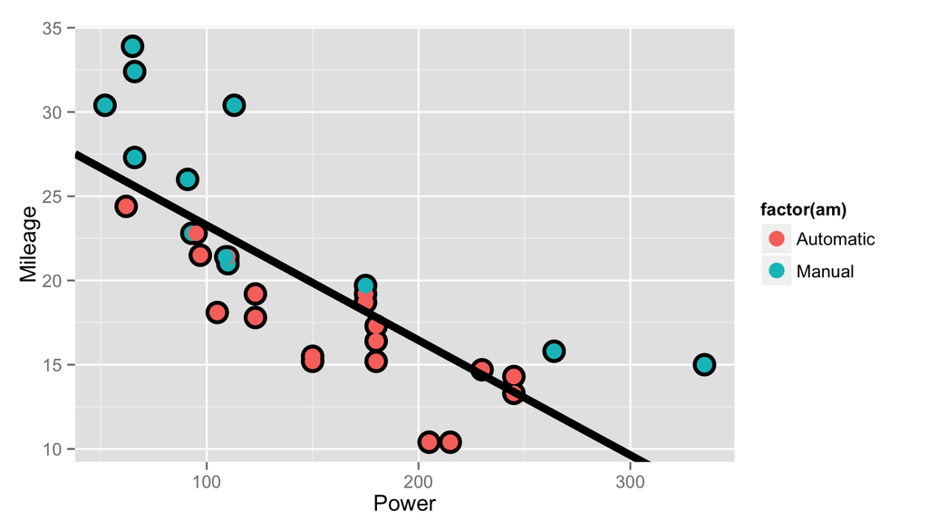

#### Miles per Gallon vs Weight

As weight increases, mileage decreases. Weight could be the highest fact that determines the fall in fuel consumptions. It is a linear down south trend noticed through regression line.

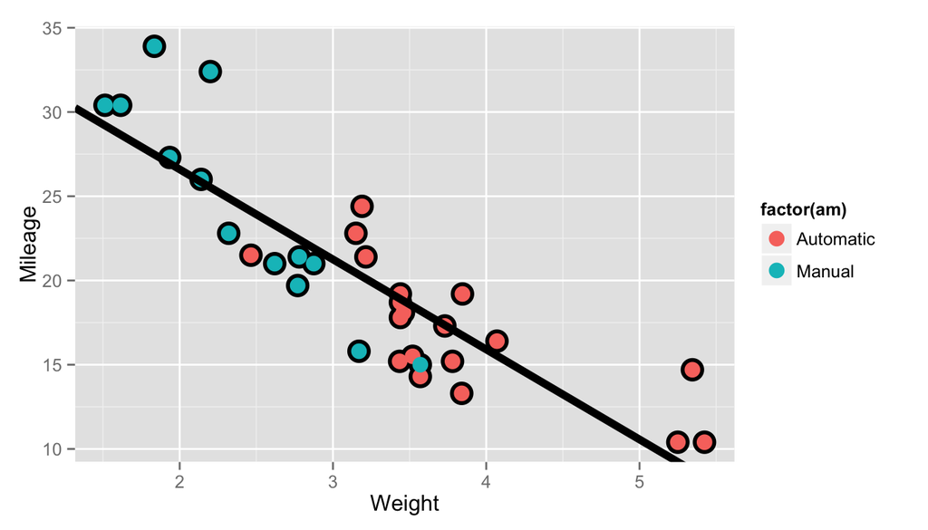

#### Weight vs No of Cylinder

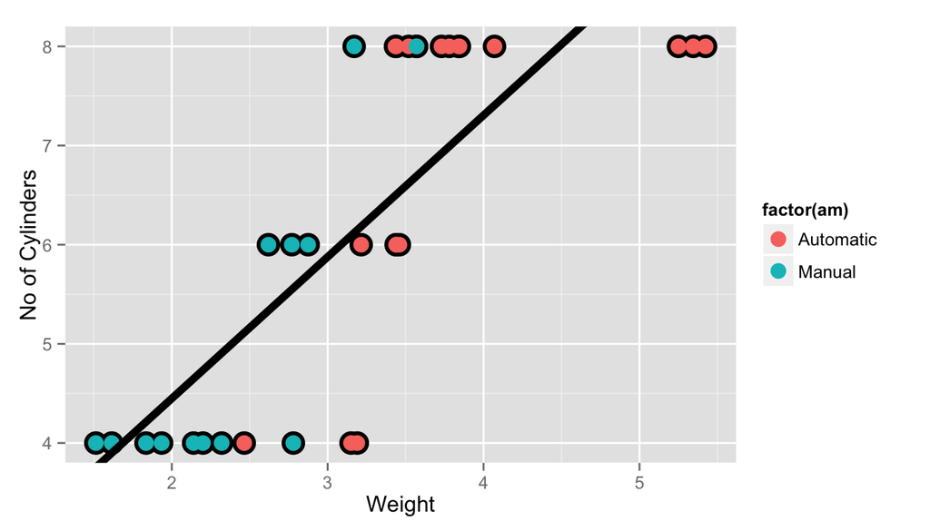

### Regression Models

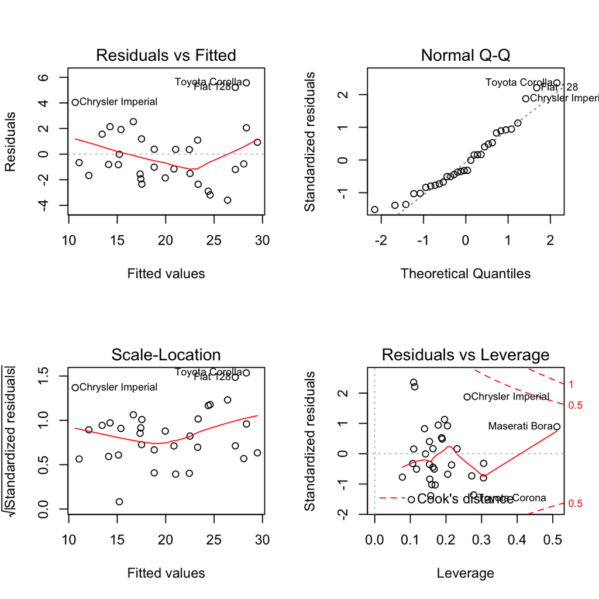